# Statistics and Writeups

Samantha Walker

2025-11-20

The goal of this class is to help us figure out how to present our results.

## Learning Outcomes:

By the end of this class, students should be able to:

- Describe modifications that can be made to R code chunks
- Explain how to write code inline with text
- Create Write Ups that combine graphs, interpretation, and analyses into a streamlined document.

## Learning Outcome #1: Describe modifications that can be made to R code chunks

Today we’re going to focus on code chunks themselves, rather than what goes into a code chunk. You’ll notice that I will be switching between knitted versions and non knitted versions throughout class. This is to help us get a sense of what these options do to our codes.

**Disclaimer:** This is going to be a brief introduction. You can write full APA style papers in R Markdown files, and this is typically easier if you use LaTex code. If you are interested in learning more about this option, here is a good resource for it: [psychstatsworkshop](https://psychstatsworkshop.wordpress.com/2016/04/24/write-apa-style-manuscripts-directly-in-rstudio/)

### Changing Code Chunks

When we are making documents in R Markdown, we don’t always want people to see all of our code and all of our output. We can modify our code chunks to make “hide” certain aspects of code.

1. **echo:**
- if TRUE, shows code in knitted file
- if FALSE, does not show code

```r
data(mtcars)
mean(mtcars$mpg)
```

```
## [1] 20.09062
```

```
## [1] 20.09062
```

2. **include:**
- if TRUE, code and output are included in the file
- if FALSE, code and output are not included in the file

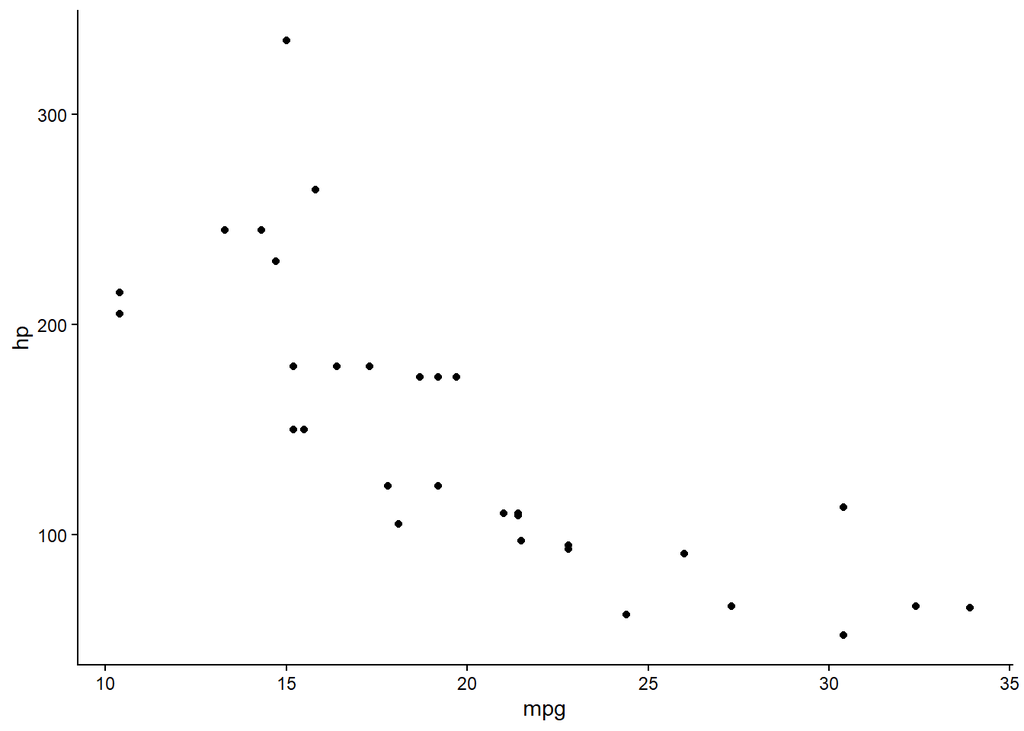

```r
#include the code and output or not with TRUE or FALSE
library(ggplot2)
ggplot(mtcars, aes(mpg, hp))+geom_point()+theme_classic()
```

3. **error:**
- if TRUE, prints error messages in document
- if FALSE, does not print error messages
4. **message and warning:**
- two separate options
- if TRUE, includes R messages and warnings in your document
- if FALSE, does not include R messages or warnings

### Practice:

Try these on your own! Create a code chunk with a graph of your favorite data this semester.

1. What happens if you use echo= FALSE? no code, but get output
2. What happens if you use include FALSE? no code no output
3. Try combining multiple arguments in your code chunk (pick your favorites).

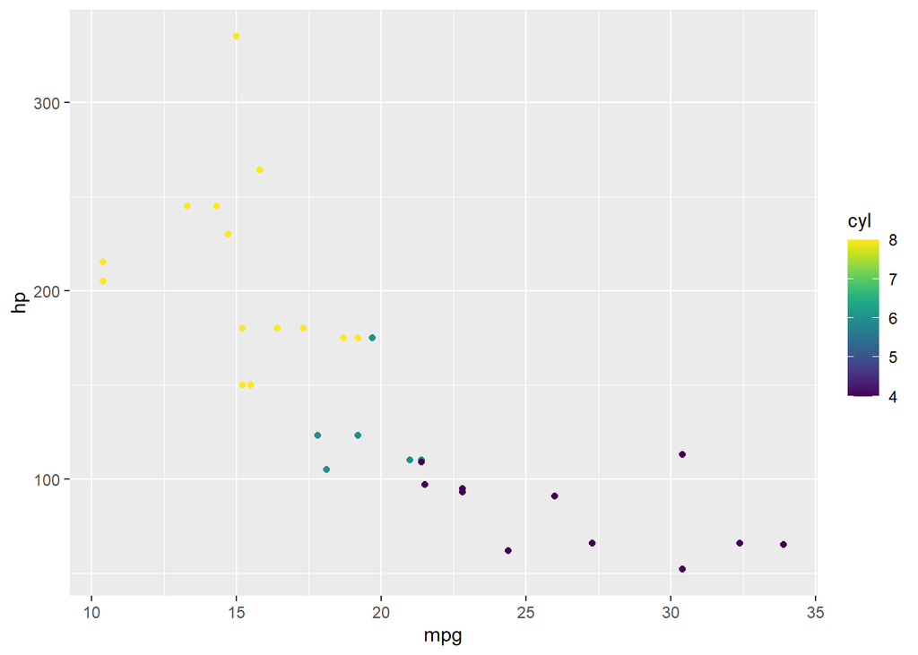

### More resources:

[The R/Posit Cloud Cheatsheets](https://posit.co/blog/the-r-markdown-cheat-sheet/) have a whole list of things you can include or not. #this is how you add links

## Learning Outcome #2: Explain how to write code inline with text

If you want to highlight something is code, but not run it, you can do something like `mean(data$column)`.

If you want to actually run R code, you need to modify it slightly to insert code here. For instance, we could do “the mean of the mpg column is 20.090625

the standard deviation of the price column is 3989.4397381

```r
correlationTest<- cor.test(mtcars$mpg, mtcars$hp)
```

the correlation from `cor.test()` is -0.7761684

the correlation is -0.7761684

### Practice:

Try Writing a sentence with any calculation you’d like in it.

The mean of depth is 61.7494049

#### More Resources

[More information about writing APA results can be found here](https://benwhalley.github.io/just-enough-r/apa-output.html)

## Learning Outcome #3:Create Write Ups that combine graphs, interpretation, and analyses into a streamlined document.

Of course, we likely want to include tables and graphs in our write ups. We can do this, but it is helpful to use multiple code chunks and save information as needed.

## Example:

#### Results:

In the current study, we had 344 penguins participate. We collected average flipper lengths, which can be seen in table 1.

**Table 1**

average flipper length

| species | meanFlipper |
| --- | --- |
| Adelie | 189.9536 |
| Chinstrap | 195.8235 |
| Gentoo | 217.1870 |

**bad table**

```r
penguinFlipper
```

```
## # A tibble: 3 × 2
##   species   meanFlipper
##   <fct>           <dbl>
## 1 Adelie           190.
## 2 Chinstrap        196.
## 3 Gentoo           217.
```

### Practice:

As a class, let’s come up with something we want to analyze and create results for from the penguins dataset.

- What’s the research question?
- descriptive statistics?
- inferential statistic?
- how to present results? (table, graph, both?!)